# data609hw3

jim lung

September 15, 2018

**113**

2. The following table gives the elongation $e$ in inches per inch (in./in.) for a given stress S on a streel wire measured in pounds per square inch ($lb/in^2$). Test the model $e=c1S$ by potting the data. Estimate $c1$ graphically.

```r
library(ggplot2)
```

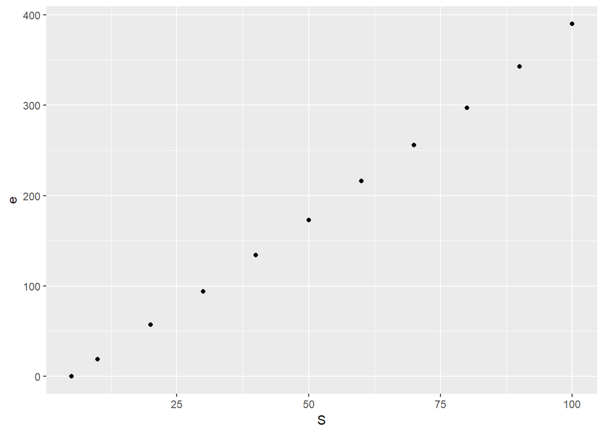

```r
S <- c(5, seq(10, 100, 10))
e <- c(0, 19, 57, 94, 134, 173, 216, 256, 297, 343, 390)

qplot(x = S, y = e)
```

Looks like a straight line. At about y = 100 it should be at about x = 30, so the slope linear model has a slope of about 3.

**121**

2a) For each of the following data sets, formulate the mathematical model that minimizes the largest deviation between the data and the line y = ax+b. If a computer is available, solve for the estimates of a and b.

```r
x <- c(1.0,2.3,3.7,4.2,6.1,7.0)
y <- c(3.6,3.0,3.2,5.1,5.3,6.8)

df <- data.frame(x,y)

lm <- lm(y ~ x, df)
lm$coefficients
```

```
## (Intercept)           x
##   2.2148534   0.5642337
```

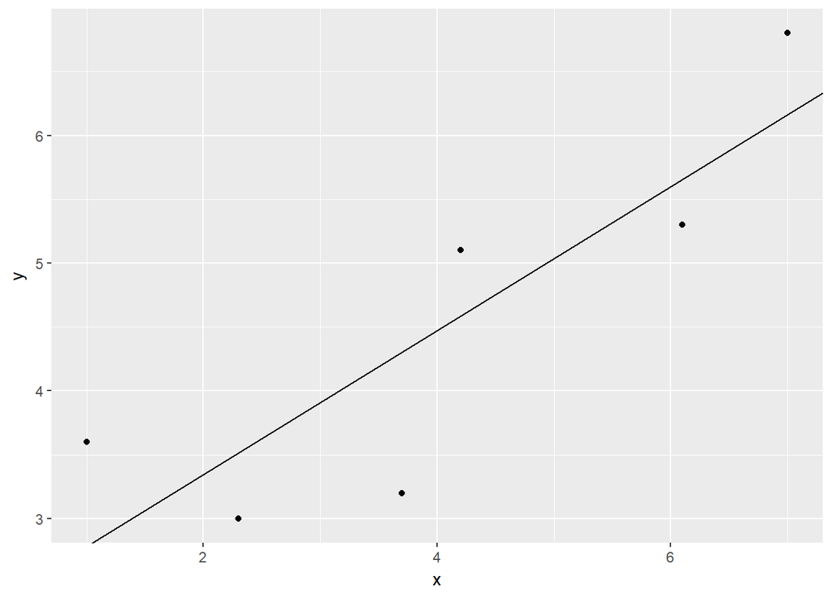

```r
f3 <- ggplot(data=df) + geom_point(aes(x=x, y=y)) + geom_abline(intercept= 2.214853, slope=0.5642337)
f3
```

**127**

10. Fit the data with the models given using least squares. Data for planets. Fit the model $y=ax^(3/2)$

```r
body <- c("Mercury", "Venus", "Earth", "Mars",
          "Jupiter", "Saturn", "Uranus", "Neptune")
period <- c(7.6 * 10^6, 1.94 * 10^7, 3.16 * 10^7,
            5.94 * 10^7, 3.74 * 10^8, 9.35 * 10^8,
            2.64 * 10^9, 5.22 * 10^9)
distance <- c(5.79 * 10^10, 1.08 * 10^11, 1.5 * 10^11,
              2.28 * 10^11, 7.79 * 10^11, 1.43 * 10^12,
              2.87 * 10^12, 4.5 * 10^12)
df <- data.frame(body, period, distance)
df
```

```
##      body   period distance
## 1 Mercury 7.60e+06 5.79e+10
## 2   Venus 1.94e+07 1.08e+11
## 3   Earth 3.16e+07 1.50e+11
## 4    Mars 5.94e+07 2.28e+11
## 5 Jupiter 3.74e+08 7.79e+11
## 6  Saturn 9.35e+08 1.43e+12
## 7  Uranus 2.64e+09 2.87e+12
## 8 Neptune 5.22e+09 4.50e+12
```

Least-squares equation for power curve where $n=3/2$, x=period and y=distance.

```r
n <- 3/2

model <- function (x, y, n)
{
  numerator <- sum(y * x^n)
  denominator <- sum(x^(2*n))
  print(numerator)
  print(denominator)
  result <- numerator / denominator
  return (result)
}

a <- model(df$period, df$distance, n)
```

```
## [1] 2.133105e+27
## [1] 1.615064e+29
```

```r
a
```

```
## [1] 0.01320756
```

```r
planet <- function(a, x, n)
{
  yestimate <- a * (x^(n))
  return(yestimate)
}

x_vals <- seq(min(df$period), max(df$period), by=100000)
y_mest <- planet(a, x_vals, n)
dfplanet<- data.frame(x_vals, y_mest)
```

Original data points and the model plotted.

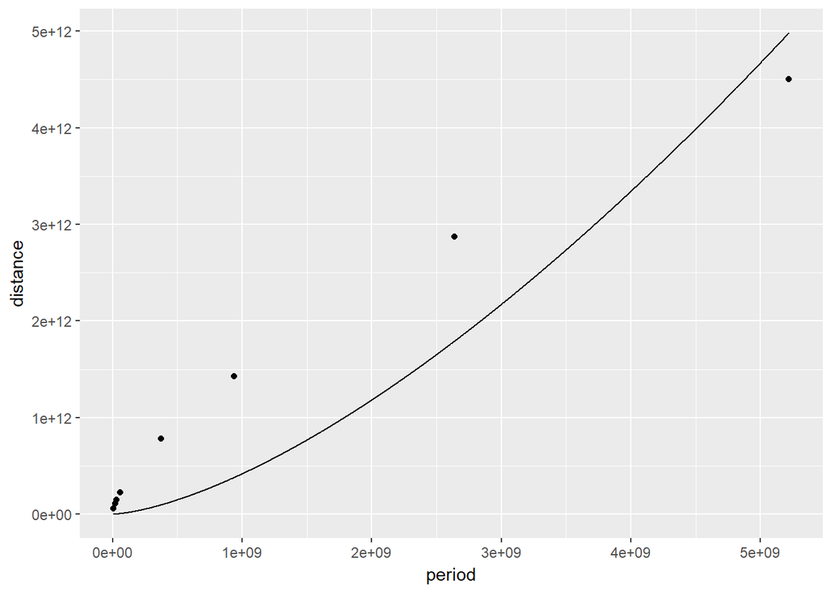

```r
f4 <- ggplot(df) + geom_point(aes(x=period, y=distance)) + geom_line(data=dfplanet, aes(x=x_vals, y=y_mest))
f4
```

Squared deviations may be minimized, but the model does not do a good job representing the data.